# Quality Assurance - Interpretability

# 1 Learning Objectives

After this module you will:

- Be aware of the key differences in interpretability and explainability
- Understand what intrinsic explaination and agnostic interpretability approaches are
- Understand the differences between local and global interpretability
- Be aware of the complexity-interpretability trade-off and how it can guide model design

# 2 Model Interpretability

We have discussed the idea of interpretability throughout the course, but in a loose sense.

In this module we will dive more into what exactly we mean by interpretability and related concepts. We will explore different approaches to interpretability that may be seen “in the wild” and limitations of some techniques. In addition, we will look at what interpretability means in the context of model design.

Model interpretability is a substantial research area, worthy of it’s own training course, we will look at the fundamentals involved and some select approaches, rather than a comprehensive investigation. For a more in depth exploration please see the book:

[Interpretable Machine Learning: A Guide for Making Black Box Models Explainable.](https://christophm.github.io/interpretable-ml-book/), by Christoph Molnar from which this module draws upon.

In this module we will focus on classical models, and tabular data for ease of explanation. There are additional approaches available for models based on text or image data, these will not be discussed.

## 2.1 Definitions

As promised, we will now look at *what we actually mean* by interpretability. The approach we are going to take is by first defining some related, but not identical concepts. This will hopefully highlight the differences with interpretability.

As mentioned, this is an area of growth for predictive modelling, with substantial research ongoing into the subject, and also [research about the research questioning the very topic itself](https://arxiv.org/pdf/1606.03490.pdf).

It’s important to keep in mind how key “interpretability” has been to the discussions of the previous modules. Can we have ethical applications of predictive modelling if we can’t interpret the results? Can we ensure we have minimised statistical bias in our model if we cannot interpret the result? A substantial chunk of our quality assurance process is dependent on this concept.

The specifics of definitions can easily fall into philosophical territory (“What does it mean, to understand?”), which we will try to avoid - being careful about terms is important, but being aware of distinctions for quality assurance is more fruitful for our purposes.

### 2.1.1 Explainability

It’s whether a model is interpretable right? No, not really.

For the purpose of this module and going forward explainability and interpretability are two separate concepts.

A model is explainable if we can define the relationship between the inputs (features) to the outputs (prediction) in a way that can be understood by a human.

This means:

- The features need to be understandable
- The way the features are combined need to be understandable
- There can’t be too many features
- **The way the model uses the features needs to be understandable**

Therefore, we don’t care if the features are combined in a linear way (such as linear regression) or are partitioned (decision tree) or other methods as long as we can see what is happening, and are able to understand it.

For example, explainable models will have some sort of structure that can be used to explain it. These will typically be:

- if-else statements
- weighted sums of features

> An example explaination for our decision tree model might be: Starting at the top of the below tree, look at the data record and follow the conditions until the end leaf node is reached, which will be the classification. If the condition is met move to the left branch below, if it is not met move right.

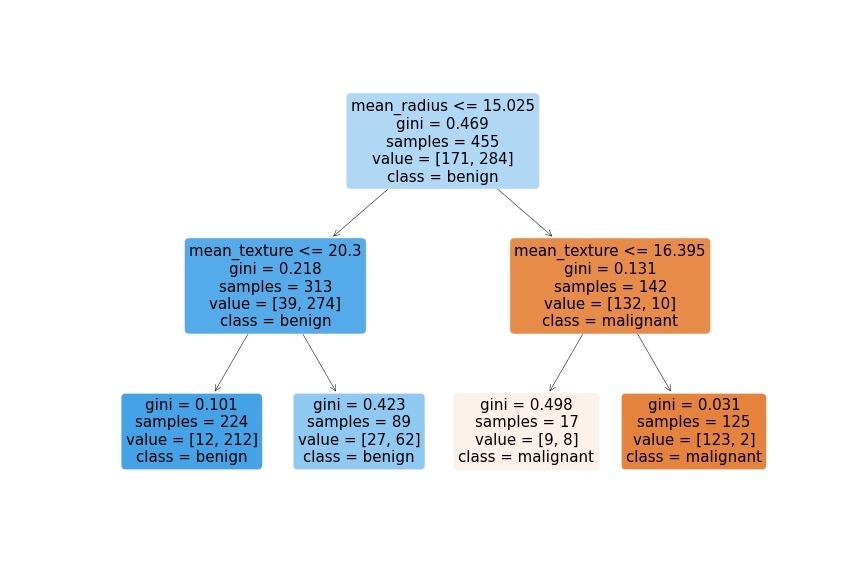

Figure 5.1: The resulting decision tree model is it’s own explaination. If we look at the decision rules themselves we can explain how an individual data point will be predicted. We can also see more information about how the model was trained, such as the number of samples at each split, and the class breakdown.

This last point **The way the model uses the features needs to be understandable** means we therefore have certain models that *can* be explainable, and *some that cannot*.

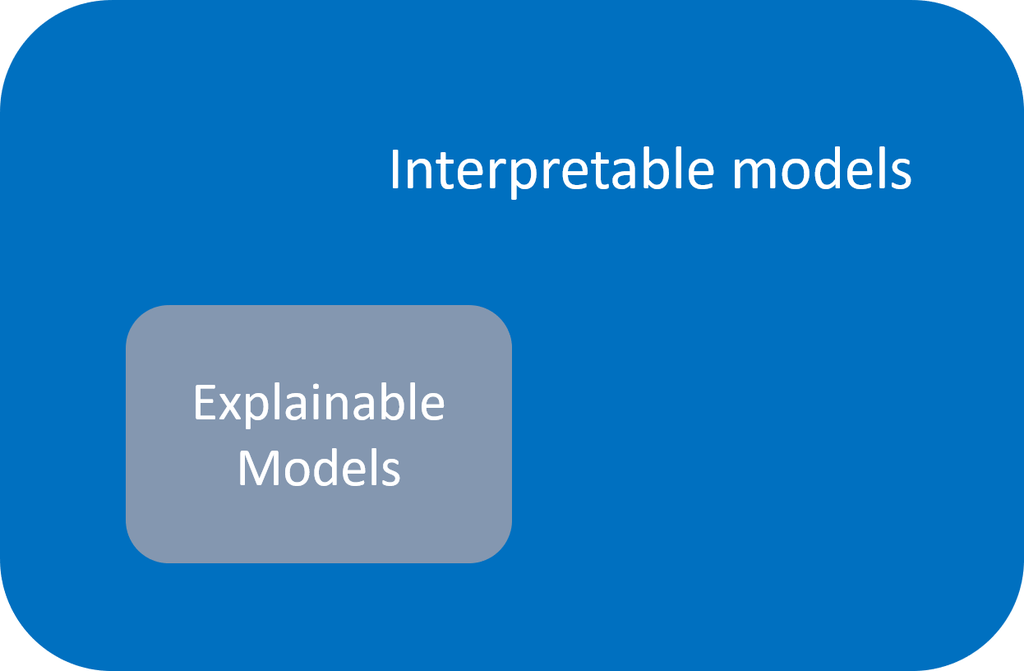

Figure 5.2: All explainable models are interpretable, not all interpretable models are explainable. Explainable models have to be a type of model that can be understood, as well as simple enough for us humans to understand the relationships found.

**Quality Questions**

Is the model selected explainable?

### 2.1.2 Interpretability

An explainable model is interpretable.

The interpretation of the model can simply be its explanation, we don’t need other approaches (methods to relate the input to the output) if it’s possible to explain directly!

Interpretability is an examination of the cause and effect between the features and prediction in a model. If one feature value increases, how does this affect the prediction.

**Note: we do not need to fully understand the relationship between feature and prediction for the model to be interpretable.** We just need to know roughly what the effect is when we change the input on the output.

So with this less rigorous definition in comparison with explainability this means:

- We don’t need to understand the structure of the model directly
- We can have as many features as needed

Therefore, all explainable models are interpretable. Explainable models are clear box model types that are human understandable.

Because methods exist to interpret black-box models, every black box model can be interpretable *to some extent*. This is because we can try to reason with the model, test it and see what the cause and effect is, without understanding what is going on inside.

For extremely large black-box models, such as [GPT-3 a text based model](https://towardsdatascience.com/what-is-gpt-3-and-why-is-it-so-powerful-21ea1ba59811), the extent of it’s interpretability will be extremely tough - but we are able to relate input to output in some ways. These models are definitely **not explainable**. Further advances in these large models, such as GPT-4, with billions of parameters, will be harder to interpret.

Models are never binary - interpretable or not. How interpretable a model is will come down to how explainable it is, and what interpretability methods used with it are useful.

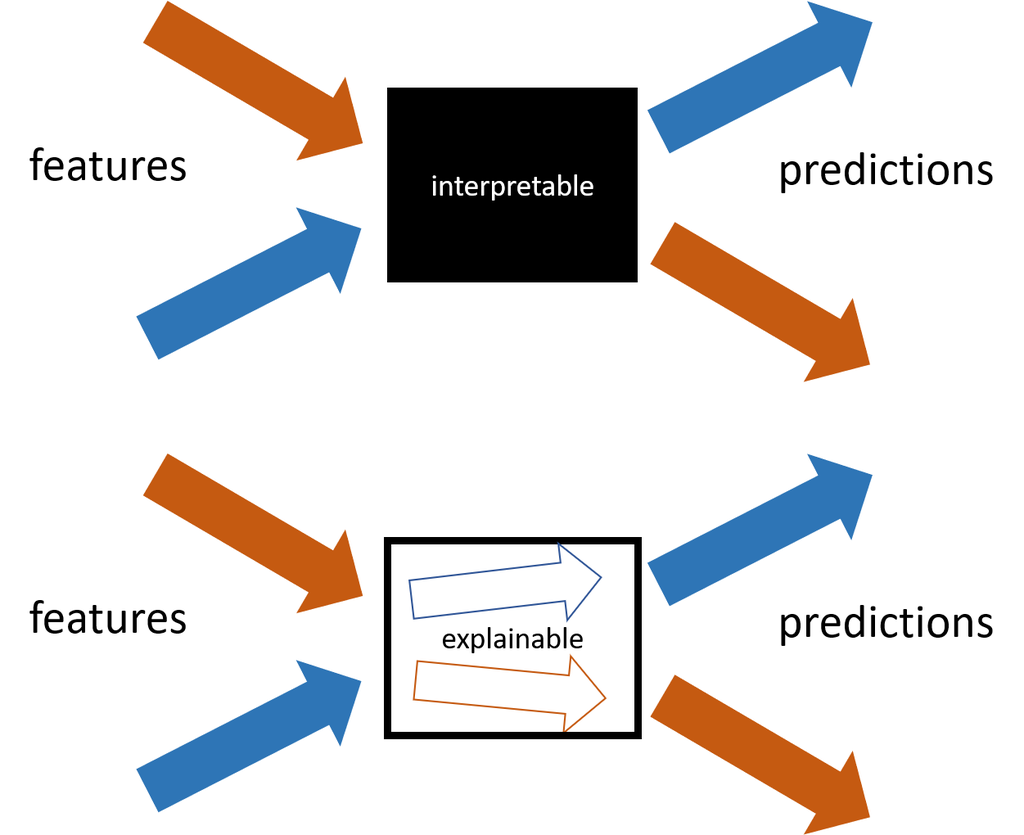

Figure 5.3: If we do not know or understand the internal workings of an unclear model we can still reason with it, understanding how changing input values changes predictions. This helps us understand more about the model, but it will never be as clear as for a clear box explainable model.

### 2.1.3 Causality

In predictive modelling, especially with machine learning approaches we need to be especially careful about making any claims of causality.

This can be tricky when we are working on “explanations” and “interpretations” of models.

Our decision tree model is not telling us that the hot weather causes more people to purchase ice-creams. It is telling us that when the weather is hot, ‘people will buy ice creams’ is a better prediction than ’people won’t buy ice creams.

By default, it’s safest to assume that any relationships found, explanations or interpretations in a model are **non-causal**. This means that we don’t know **why** something happened, we are not making claims about how the features **cause** the outcome, but rather that there is a coupling / covariance.

Typical machine learning models take advantage of **correlations** between features, **not causation**. The patterns found in the data by the model mean that $A$ could impact $B$, or $B$ could impact $A$, we cannot know which way from the model.

If we want to make causal inferences about our prediction systems, we need to have used appropriate methodologies.

Therefore, our interpretations and explanations should steer clear of causality, especially when we communicate with stakeholders or else we may give false impressions about our model.

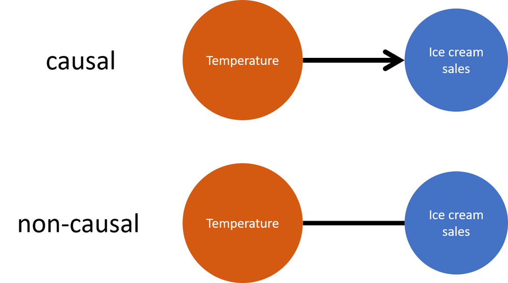

Figure 5.4: While our predictive model may be explainable or interpretable, we need to ensure we don’t make untrue claims about causality between features and predictions. Did the feature cause the phenomena, or did it cause the model to predict differently? Normally the later.

**Quality Questions**

Is the language of causality appropriate to this task?

## 2.2 Discussion

**Question**

Classify the following statements as **“explanation”, “interpretation” or “causation”**.

- The increase in temperature causes more people to buy ice creams.
- The coefficient of the temperature variable is 0.42, meaning for every unit increase in temperature the log-odds of purchasing an ice cream increases by 0.42.
- As the temperature increases the model predicts a purchase of ice cream with a higher probability.

**Answer**

- **Causation** - The increase in temperature causes more people to buy ice creams.
- **Explanation** - The coefficient of the temperature variable is 0.42, meaning for every unit increase in temperature the log-odds of purchasing an ice cream increases by 0.42.
- **Interpretation** - As the temperature increases the model predicts a purchase of ice cream with a higher probability.

The first states that there is a cause and effect in the actual phenomena, rather than about the model. We can likely not work this out from a predictive model.

The second uses the inherent explanation of the model (a logistic regression in this case) to describe how the model works.

The third links a relationship between the feature and prediction, but doesn’t explain it.

# 3 Model Agnostic Approaches

Part of the challenge with clear box, explainable models, is that while it is extremely useful we can explain how they work, different model types need to be explained differently.

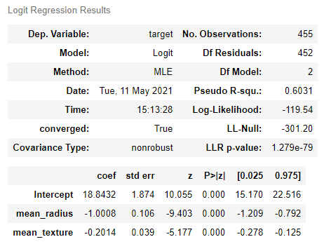

Figure 5.5: Logit regression results showing significant coefficients “mean_radius”, “mean_texture” and the intercept at the 95% significance level.

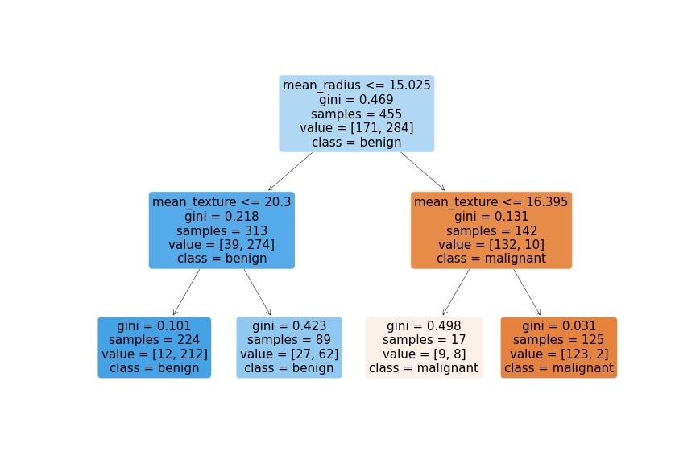

Figure 5.6: The same data and coefficients from above instead used as a set of decision rules for a decision tree, which are more explainable but completely different in how we interpret them. Here, the first split from the root note is dependent on whether the mean_radius is less than or equal to 15.025 etc.

This means when we compare different model predictions, the framework of how we explain those predictions is different for each model type. Comparing a linear regression’s explanation directly with a decision tree’s explanation is not possible. They are too differently structured.

Instead, we can choose to interpret the model’s predictions using a common framework across different model types. By definition these “model agnostic” approaches:

- work for a range of model types
- are not explanations, but interpretations - relating input to output

Model agnostic approaches work *in theory* for all model types that create predictions.

**They do not depend on individual model structures or values** to interpret the results.

As model agnostic approaches are not dependent on the internal workings of the model in question, they can be used for both *explainable* and *non-explainable* model types. This allows the **interpretation of the models to be comparable**.

If in one model a certain feature has a big impact on the prediction, but not in a different model, that is something we want to know because it tells us where an uncaptured phenomena or error may be present.

**Quality Questions**

How are different model types going to be compared? Is predictive performance alone appropriate?

## 3.1 Feature Importance

One of the most common ways to interpret a model (remember - relating the feature to the output) is to investigate the importance of each of the model’s features on the error of the model.

Specifically we will look at a frequently used method **“Permutation Feature Importance”**.

No interpretation approach is perfect, we will discuss the limitations of this methods shortly.

What this interpretation tells us is **how much worse does the model get if we remove this specific feature**.

- By “remove” in this case, we mean **randomly shuffle** hence, “permutation”
- By “worse” we mean, how much does the error increase

So the method goes through the models features, shuffles the inputs (effectively removing it), to determine how much worse the predictions get without it. If the model gets significantly worse without a certain feature, then it must be an important feature!

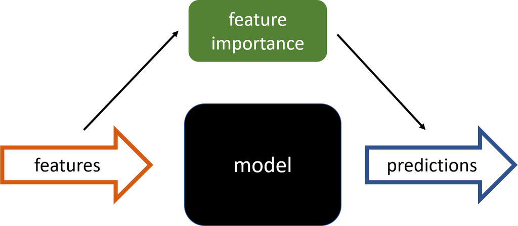

Figure 5.7: The feature importance approach can give us insight into how the model takes into account different features and what it values. This is done without editing the model directly or requiring any specific structure.

The importance of each feature can then be compared. As we are not directly interacting with the model, just changing it’s inputs and observing the outputs, we do not need to retrain the model and can compare the importance of different features between models.

It’s important to note that this tells us **how important** the feature is to the model. This doesn’t tell us what the relationship is (does the prediction go up or down, for example). If we have features that aren’t important to our model’s prediction, why keep them?*

* Every method has draw backs, investigate further before just dropping a features. It’s most important we do a full evaluation of the model if we change it’s feature inputs.

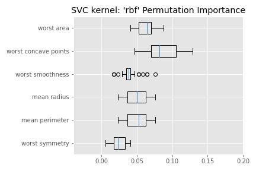

We would easily be able to explain the logistic regression model’s prediction by looking at it’s coefficients. However, we may have struggled with the support vector machine as it uses a kernel (radial basis function in this case) to transform the data. Using this feature importance approach lets us compare very different models on a level playing field.

**Drawbacks**

Permutation importance is a good method, but as with all approaches the benefits come with risk/challenges.

- **Correlation** - if two features are highly correlated and important they will not have high importance as one is a proxy for the other, the error will not decrease when one is removed significantly.
- **Variation** - this method tells us what is important, not *how* it is important. We cannot see how the output changes with different feature values.

In the example figure we have two features “mean radius” and “mean perimeter”. Assuming that cancer/non-cancer cell’s perimeter is some function of it’s radius (if they are circles then the relationship will be $perimeter = 2 \pi r$). This means that the two features will be highly correlated, reducing the feature importance of each feature. Multicollinearity is a common problem in modelling, and it rears it’s head frequently in predictive modelling evaluation.

This of course doesn’t mean our approach is bad, but rather we shouldn’t use any interpretation in isolation, especially when there are known issues that we can check for.

**Quality Questions**

Is the importance of a feature useful to us?

How has high correlation been mitigated / explored in this case?

# 4 Global and Local interpretability

There are many different ways we can split up interpretable approaches. One of the most useful is whether the interpretation they give us is for **the model as a whole** or for **individual instances**.

- **Global** interpretations tell us how the features relate to the predictions overall
- **Local** interpretations tell us how the features relate to an individual prediction produced by the model

Both of these types can be useful. The permutation feature importance method shown was an example of a global interpretation of the model.

When we use global interpretation methods there can be aggregation, which means some interesting patterns may be hidden. However, for local methods trying to discern the signal from the noise can be a challenge.

In practice, we should:

- Consider the purpose of our interpretation, are we trying to understand the model’s characteristics in the round, or give reasoning for an individual prediction?
- Use both! We need a mix of interpretations to give a more complete understanding of the model. There are no silver bullets for evaluation or inspection of models, just some approaches more aligned to our goals than others.

It’s important to note that **explainable models have both global and local interpretations built-in***. The beauty of an explainable model (or one of at least) is that as we can *exactly* understand the inner workings of a model, we can therefore look at how the model related features to the prediction, but also work out for any individual prediction what will happen.

As with all sweeping statements in this course, there are of course exceptions. For example a very explainable model, the K-Nearest Neighbour algorithm by definition only has a local explanation. Every prediction is dependent on training examples nearby the prediction point, not on any global structure.

## 4.1 Partial Dependency Plot - Global

Another frequently used interpretability approach is that of the partial dependency plot, a **global** method.

A partial dependency plot effectively sets all but one features constant (marginalises, taking an average), and looks at the variation in prediction when one feature changes. This way the resulting variation in prediction only depends on the single feature we are exploring.

The mathematics behind how this marginalising on other features work is very interesting, but well beyond the scope of this course. For further information, see the the suggested [Interpretable ML book for this module](https://christophm.github.io/interpretable-ml-book/pdp.html).

What the partial dependence does for us is shows how a variation in the feature impacts the prediction. We get a plot of feature (x-axis) and prediction (y-axis). The relationship that is shown between the feature and prediction will be dependent on the model used. A linear regression can only show a straight gradient relationship between single features and the outcome. More non-linear models will show more interesting relationships between the feature and prediction as they are not constrained to linearity.

Note that for the below figures we have standardised the features (mean centered, standard deviation of 1), to allow for more meaningful comparison between features. Doing so is not necessary for all model types.

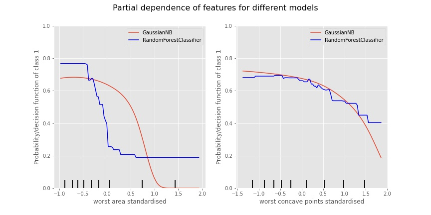

Figure 5.9: The black lines at the bottom of the blot are deciles of the feature distribution, which helps us understand what our data has been trained on. Looking at how the partial dependence (probability of prediction) changes with the value of the feature according to our model will help use understand how it predicts.

An interpretation of the differences between the two models would be:

- Both agree as the features increase the probability of class 1 decreases.
- The NB model has a more smooth / gentle gradient of partial dependence.
- Above -0.5 “worst area standardised” the random forest model sharply drops prediction probability.
- There is a region of “worst area standardised” where the models disagree significantly (0.0 - 0.5).
- The NB model’s probability tends towards zero for each feature where there is less data, whereas the the random forest has a constant probability in regions of no data.

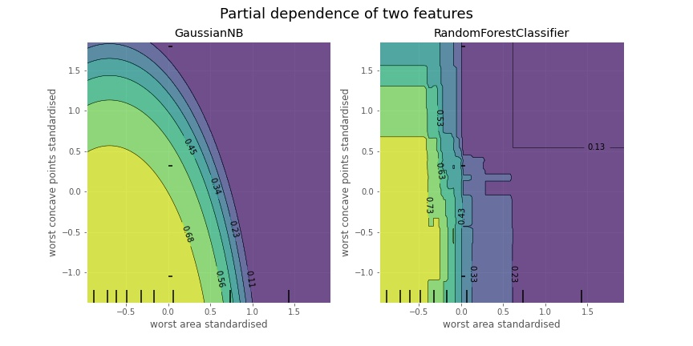

Figure 5.10: Plotting the partial dependence of two features against each other allows us to understand how they might be related, and where predictions may differ.

From this plot we might conclude that:

So overall, we can get some interesting information about our model from these partial dependence plots. We can understand on average, how the prediction of a outcome changes with an individual feature. This is a great, simple model that is frequently used and easy to implement. We can easily see what happens to the prediction if we increase the value of a feature.

It’s really key we have some information on the plot (such as our deciles shown) which help us relate the distribution of the data to the partial dependence. **We don’t want to infer a relationship in a model that exists because of a lack of data.**

There are however, some issues with interpreting these models using this method alone.

**Drawbacks**

- Again, if our features are correlated this method will give misleading results. By looking at features individually we are assuming independence, which is not always true. If we have temperature and humidity as variables, but it’s never 100% humidity (rain maybe), when it’s 50 Celsius outside then when we average the features we are including impossible information, skewing the result. We need to treat highly correlated features carefully always!
- By taking an average of features we can lose useful information about our relationships. Positive features effects combined with negative feature effects will average to no effect, giving a misleading interpretation of the model. We can mitigate this by using… local methods!

**Quality Questions**

What is this interpretation method hiding?

## 4.2 Individual Conditional Expectation - Local

Local interpretability methods allow us to examine how the model behaves with reference to **specific data points**. This means we are not taking averages of aggregates, but rather looking at the real instances.

By doing this we are able to both:

- Avoid mixing effects due to aggregation.
- Understand how a specific instance will be treated by the model.

The local method we will first explore is the direct mirror of the global partial dependence plot.

Individual Conditional Expectation (ICE) lets us take a data point, vary one feature, and see what the response is on the prediction. This way we do not average the feature values. We can then plot many points at once to see patterns in the relationships, without losing information to aggregation.

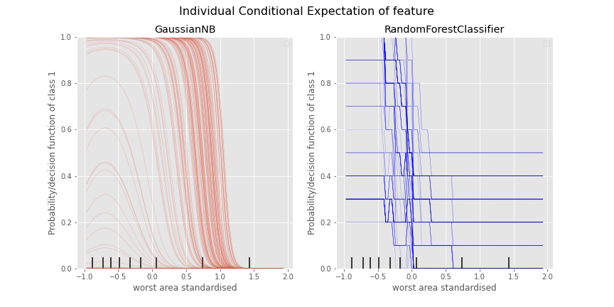

Figure 5.11: Looking at individual predictions and how they change when a single feature changes tells us more about the models decision making process. Notice the thick line at $p=0$ for the NB model, some of our predictions are invariant to the feature in question. For some values of the random forest model the prediction can go down, then up then down as the feature value increases. Some instances of the random forest model change significicantly with feature values, some not at all. This is because the model is dependent on many other features we cannot inspect at once.

There are some interesting phenomena occurring in figure 5.11. The NB model has some values with a clearer peak probability not shown in the PDP plot. We have very high probability values for some instances with the NB model, and some with 0, which averaged out causes us to lose this information.

Remember our data is dependent on a range of features, so some of the feature values we create in this method may not be plausible in reality, but do represent what the model thinks will happen.

The random forest model can be more challenging to interpret in this case, due to the discrete nature of the decision rules causing overlapping line plots. What we can see is that large changes in the feature do not cause huge changes in the probability, but rather a step change down (typically). In combination with other features this is useful for predicting the outcome well.

In practice, we can use both the PDP and ICE plots at once. This gives us the best of both worlds with regards to aggregation. However, we should still be concerned about correlation.

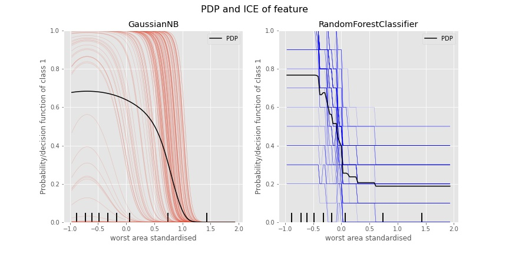

Figure 5.12: Showing both the PDP and ICE approaches gives us a more complete picture of the relationship between the model, feature and prediction.

**Only by looking at the model from a global and local perspective can we be assured that it does what we think it is doing, in a range of cases.**

What we should hopefully take away from this section is that:

- There are a variety of approaches to model agnostic interpretation, not one single source of the truth.
- There is no *silver bullet* - one single method for interpreting a model, all have drawbacks and benefits.
- A combination of interpretation methods helps tease the most possible useful information from the model.

**Quality Questions**

What is more important for our purpose, to interpret the model globally or locally?

## 4.3 Discussion

**Question**

How can we take the model structure into account when viewing the relationships between features and prediction?

**Suggestion**

Model structure defines what the relationship found will be. Therefore the interpretation of the model is tied to what structure is chosen.

We shouldn’t try to interpret the relationship without a basic understanding of the model structure.

If we use a linear model, we will find a linear relationship in the interpretation. This does not mean that the **true** relationship is linear necessarily.

If we use a decision tree based model, we will have discrete-step like relationships found. Again, this doesn’t mean that the true relationship is of this format.

When we create a predictive model, we are trying to approximate the true relationship.

This means we should be careful when reporting what the relationships found between features and predictions. If we have different model structures we can compare and contrast the general trends, which together will give us insight and allow us to look for reasons why their predictions may differ.

# 5 Complexity vs Interpretability

There is often stated a *Complexity / Accuracy* trade-off in predictive modelling. We will push back against this way of thinking about modelling.

More complex models are not inherently more accurate than simpler models. More complex models can improve accuracy when the simple model **cannot approximate the true relationships under study**.

Instead, we will focus on the more useful framing of *“The higher the complexity of the model, the harder it is to interpret”*. Carefully here we have not used “explain” in that sweeping statement, although as we know they are related. A highly complex model can be an explainable model type, but still challenging to understand.

Let us recap some of the factors which can increase the “complexity” of a model:

- Large numbers of features - creates a larger model
- Unclear / intangible features - makes it hard to relate real quantities to the prediction

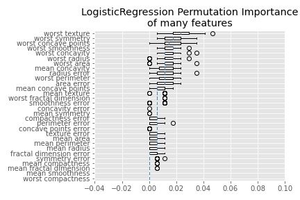

We often need to make an assumption about our models and the independence of the features we have given. As we have seen with the feature importance and PDP approaches, if this assumption is not held it causes an issue of interpretation. When our model takes features that are not independent of one another, this greatly increases the complexity of the model. We need to be careful about whether our features are independent, and therefore what conclusions we can draw from the model.

We previously stated that learning algorithms that are difficult to understand are complex, however, now we know about model agnostic methods for interpretability, this is *slightly* less of an issue.

The key takeaway of the previous sections regarding complexity was:

**Use the most simple model that achieves the desired performance level.**

The simpler the model, the easier it will be to interpret the model.

## 5.1 Agnostic Benefits

We have mentioned again that feature complexity, using features that are difficult to understand themselves, can be a challenge to explain.

No matter how explainable the model is (such as a decision tree), if we put the data through a complex transformation before giving it to the model then it will be difficult to use the model’s inherent explanations.

Model agnostic methods can be used in this case, because we can treat the data transformations as part of the overall model. We can encapsulate the data processing and model within one single object, rather than consecutive processing steps. This makes it much easier to relate input features to output predictions.

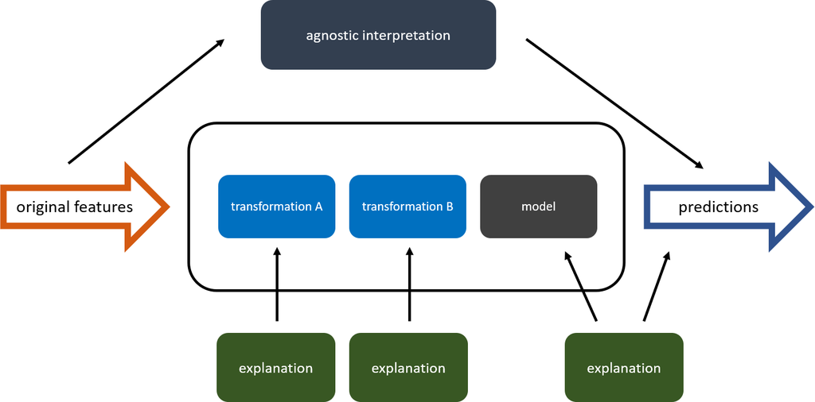

Figure 5.14: Assuming the method is explainable, we can explain individual steps in the model system, however it isn’t feasible to explain all steps at once. Interpretation methods can treat all the processing steps as one model, allowing us to relate the original features to the predictions.

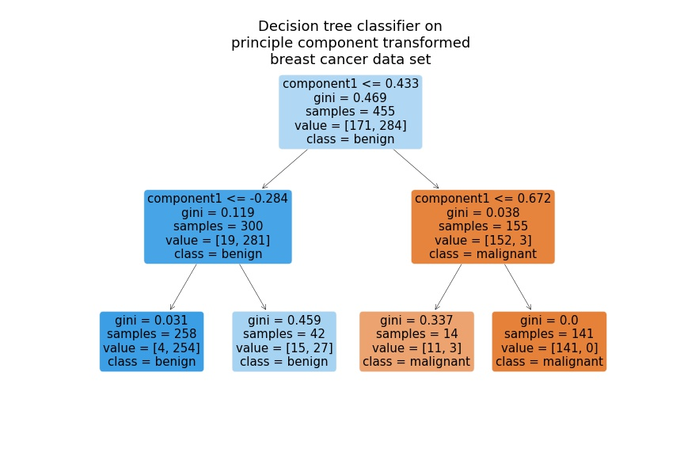

Figure 5.15: Even in an explainable model, using an obscuring feature transformation will make it difficult for us to relate the original observations to the prediction. The model’s performance may improve by adding this transformation, which means it should be considered with the obscuring trade-off.

Using a model agnostic approach means we can still relate the original features to the prediction regardless of what model **or transformation** happens in between. In the example above, we could analyse the principle components one-by-one to explain why the prediction happens, which is often needed, however we can interpret end-to-end with an agnostic approach.

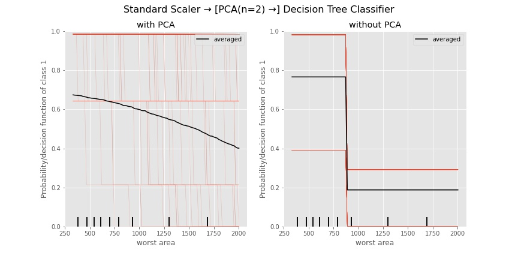

Figure 5.16: Using a transformation pipeline we can interpret our feature regardless of what steps we follow in the model prediction. In this case we are standardising the features, then performing principle component analysis, then predicting using the decision tree classifier. This allows us to more easily compare different model design choices on more than just prediction score.

So we have to some degree mitigated the challenge of unclear features, by using an interpretability approach which compares the original values to the prediction, rather than any intermediates.

Again, the most interpretable model is an explainable model, which we should always either start with, or benchmark against depending on the requirements of our problem.

Interpretable methods are about getting the most understanding out of the model possible, using a range of approaches. However, it will always be impossible to fully explain a prediction if the model is not inherently explainable.

**Quality Questions**

Has the analyst shown how the model inputs relate to the predictions?

If there are too many features to clearly interpret the model, is this justifiable?

## 5.2 Further Methods of Interpretability

This course is not intended to teach interpretable methods in a detailed manner, and therefore we have just looked at methods which are conceptually useful and easier to understand. For further exploration of interpretation approaches see the [Interpretable Machine Learning book](https://christophm.github.io/interpretable-ml-book/agnostic.html).

There are a few other points are key when further exploring this topic:

- Explainable/clear box models are an increasingly large area of research, but classical statistical learning algorithms are a great place to start.
- Algorithms to help interpret black box models are also an active area of research. There are disagreements in what is preferred, and not all agnostic methods are available in common / assured software packages.
- We have only explored methods relevant to tabular data, for unstructured data there are a range of other approaches which may be more useful.

# 6 Summary

In this module we have explored what is meant by interpretability, a commonly discussed topic on predictive modelling.

We looked at how explainability, interpretability and causality differ, and why that’s important.

Model agnostic approaches to interpretability were introduced, with the example approaches of permutation feature importance, partial dependence plots and individual conditional expectation. Through these last two approaches we discussed the importance of both global and local types of interpretability, and how looking at just one approach can be misleading.

To finish we revisited the idea of model complexity, and introduced how agnostic methods for interpretability can help us shine a light into some difficult to explain processes in the prediction pipeline.

Crucially, throughout we have highlighted that there are no perfect interpretation methods. We want models to be explainable in the first instance, but if we do need to use a more opaque model type we have ways to mitigate this.

Next chapter we will look at model maintenance:

The value of a predictive model comes from it’s use. In order to actually deploy a predictive model we need to take into account important software development + operational principles. Having a prediction system working over time introduces new challenges around maintenance and bias, which will be discussed.